# Ford GoBike Project: Communicate Data Findings

## by Che-Hsien Lin

## Investigation Overview

> I chose Ford GoBike data for my Communicate Data Finding project. I wanted to find out the trend of this service from 2018 to early 2019 by specific age groups, genders, and member type.

## Dataset Overview

> There are 2,239,215 entries and 16 columns in the raw data. After filtering it by choosing the age group <= 60 for male and female (excluding others), and drop unwanted columns (station name & latitude & longitude), there are 2,024,988 entries and 7 columns remained for the further analysis.

## Age distribution of all users

> The age of the major user group is <= 60. Some of the users' age are too old (greater than 100). My later investigation will only focus on the major users (<= 60).

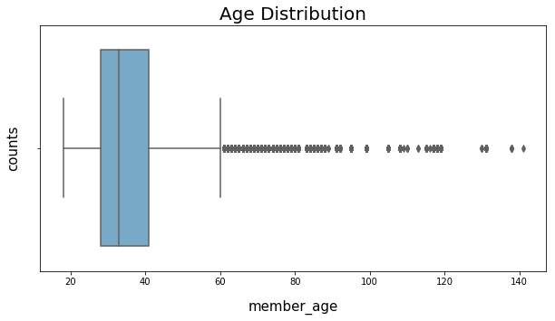

```python
# View the age distribution from a boxplot.
plt.figure(figsize=(10,5))
sns.boxplot(x='member_age', data=df, palette='Blues', orient='h')
plt.title("Age Distribution", fontsize=20, y=1)
plt.xlabel("member_age", fontsize=15, labelpad=15)
plt.ylabel("counts", fontsize=15, labelpad=15);
```

## Distribution of gender

> There are about 75% male users and 25% female users in the major group.

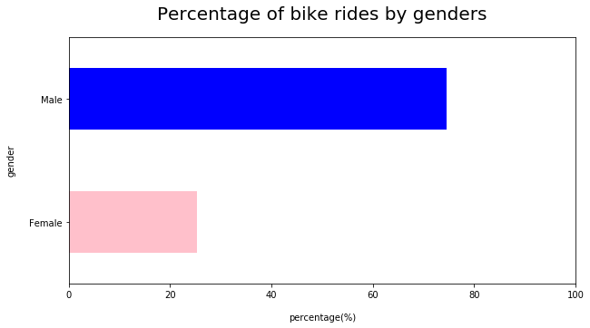

```python
# Create a barchart-h base on different genders
barh_color = ['pink','blue']
trip_by_gender_df['perc'].plot(kind='barh', color=barh_color, figsize=(10,5))
plt.title('Percentage of bike rides by genders', fontsize=20, y=1.05)
plt.xlabel('percentage(%)', labelpad=15)
plt.ylabel('gender', labelpad=15)
plt.xticks(rotation=360)
plt.xlim(0,100); # Show 100% as limit for a better overview.
```

## Distribution of weekday

> People ride much more often during the weekday than weekend. During the weekday, people are less active on Monday and Friday.

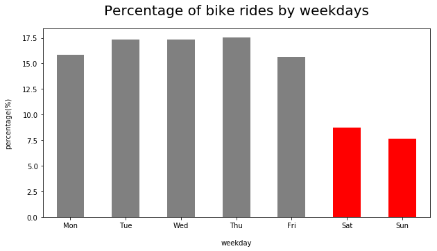

```python
# Create a barchart based on different weekday.
weekday_color = ['grey', 'grey', 'grey', 'grey', 'grey', 'red', 'red'] # Show the weekend as red color.
trip_by_weekday_df.reindex(weekday_index)['perc'].plot(kind='bar', color=weekday_color, figsize=(10,5))
plt.title('Percentage of bike rides by weekdays', fontsize=20, y=1.05)
plt.xlabel('weekday', labelpad=15)
plt.ylabel('percentage(%)', labelpad=15)
plt.xticks(rotation=360);
```

## Distribution of the hours of a day

> The peak hours of bike ride are 7-9 am and 5-7 pm which are generally the commuting hours.

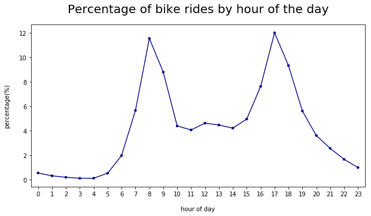

```python
# Create a pointchart based on different hour of a day.
plt.figure(figsize=(10,5))
sns.pointplot(data=trip_by_hour_df, x='start_time_hour', y='perc', scale=0.5, color='navy')
plt.title('Percentage of bike rides by hour of the day', fontsize=20, y=1.05)
plt.xlabel('hour of day', labelpad=15)
plt.ylabel('percentage(%)', labelpad=15)
plt.xticks(rotation=360);
```

## Average trip duration of subscribers & customers

> For subscribers, the average trip duration per ride is about 11 minutes; for customers, the average trip duration per ride is about 26 minutes. The behaviral difference is due to the pricing plan. Customers pay 2 dollars per trip for the first 30 minutes, but they have to pay 3 dollars for 15 minutes after that which is not cost-efficient. Subscribers don't have the concern because they pay 15 dollars per month and they can ride up to 45 minutes per ride and unlimited rides during the month.

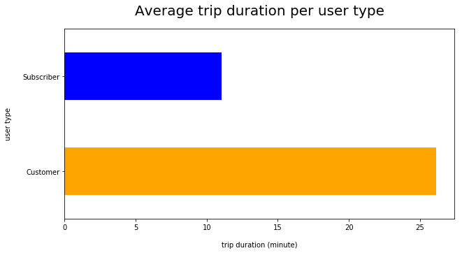

```python
barh_color = ['orange', 'blue']
df.groupby('user_type')['duration_min'].mean().plot(kind='barh', color=barh_color, figsize=(10,5))
plt.title('Average trip duration per user type', fontsize=20, y=1.05)
plt.xlabel('trip duration (minute)', labelpad=15)
plt.ylabel('user type', labelpad=15)
plt.xticks(rotation=360);
```

## The trend of subscribers' & customers' rides per age group

> The major age group is 20-40 and the trend is going upward. The trend of other age groups don't change much. From May to October are the high seasons for the bike ride. The trend is similar for both subscribers and customers.

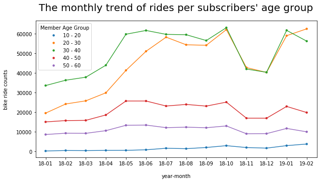

```python
# Generate a pointplot for viewing the trend of bike rides for subscribers.
plt.figure(figsize=(10,5))
ax = sns.pointplot(data=subscriber_df, x='start_time_year_month_renamed', y='bike_id', scale=0.5, hue='member_age_bins')
plt.title("The monthly trend of rides per subscribers' age group", fontsize=20, y=1.05)
plt.xlabel('year-month', labelpad=15)
plt.ylabel('bike ride counts', labelpad=15)
plt.xticks(rotation=360)
legend = ax.legend()
legend.set_title('Member Age Group');
```

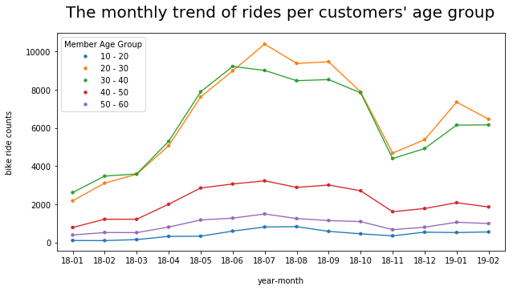

```python
# Generate a pointplot for viewing the trend of bike rides for customers.
plt.figure(figsize=(10,5))
ax = sns.pointplot(data=customer_df, x='start_time_year_month_renamed', y='bike_id', scale=0.5, hue='member_age_bins')
plt.title("The monthly trend of rides per customers' age group", fontsize=20, y=1.05)
plt.xlabel('year-month', labelpad=15)
plt.ylabel('bike ride counts', labelpad=15)
plt.xticks(rotation=360)
legend = ax.legend()
legend.set_title('Member Age Group');
```

## Age group, weekdays, hour of a day effects on bike rides

> I chose to investigate subscribers' relationships among age groups, weekday, and the hour of a day. I generated a heatmap based on the rank and values above. The heat maps of four age groups all show that the peak hours are during 7-9 am and 5-7 pm from Monday to Friday, which is generally the time of commuting and working. During the weekend, people behaved differently. They rode much less than the weekday and no longer rode much during commuting time. In the group of age 40-60, the color distribution of the heatmap shows that higher rate of the people rode during non-commuting hours.

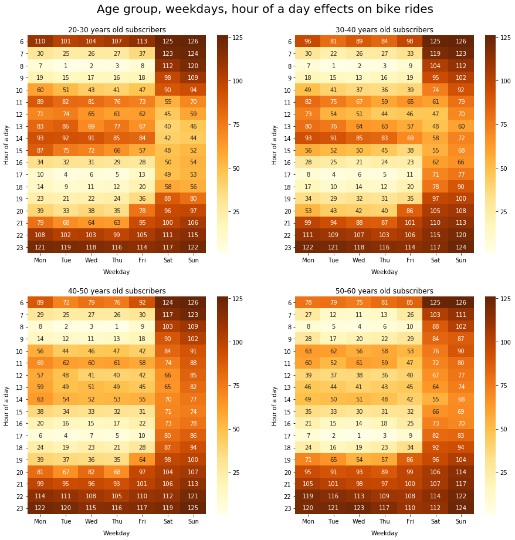

```python
# Create for heatmaps for four different age groups based on rank, weekday, and hour of a day. Higher the rank, brighter the color, means users rode more often in the time zone.
plt.figure(figsize=(15,15))
plt.subplot(221)
plt.suptitle('Age group, weekdays, hour of a day effects on bike rides', fontsize=20, y=0.93)
sns.heatmap(subscriber_df_1_pivot, fmt='d', annot=True, cmap='YlOrBr', annot_kws={'size': 10})
plt.title('20-30 years old subscribers')
plt.xlabel('Weekday', labelpad=10)
plt.ylabel('Hour of a day', labelpad=10)
plt.yticks(rotation=360)

plt.subplot(222)
sns.heatmap(subscriber_df_2_pivot, fmt='d', annot=True, cmap='YlOrBr', annot_kws={'size': 10})
plt.title('30-40 years old subscribers')
plt.xlabel('Weekday', labelpad=10)
plt.ylabel('Hour of a day', labelpad=10)
plt.yticks(rotation=360)

plt.subplot(223)
sns.heatmap(subscriber_df_3_pivot, fmt='d', annot=True, cmap='YlOrBr', annot_kws={'size': 10})
plt.title('40-50 years old subscribers')
plt.xlabel('Weekday', labelpad=10)
plt.ylabel('Hour of a day', labelpad=10)
plt.yticks(rotation=360)

plt.subplot(224)
sns.heatmap(subscriber_df_4_pivot, fmt='d', annot=True, cmap='YlOrBr', annot_kws={'size': 10})
plt.title('50-60 years old subscribers')
plt.xlabel('Weekday', labelpad=10)
plt.ylabel('Hour of a day', labelpad=10)
plt.yticks(rotation=360);
```